# Proyecto Teoria de series de tiempo univariadas

Luis Mantilla, Bryam Bustos y Pedro Leal

2024-03-04

# Subir datos

```r
library(forecast)
library(lubridate)
library(readr)
datos_inflacion <- read_csv("datos_inflacion.csv")
```

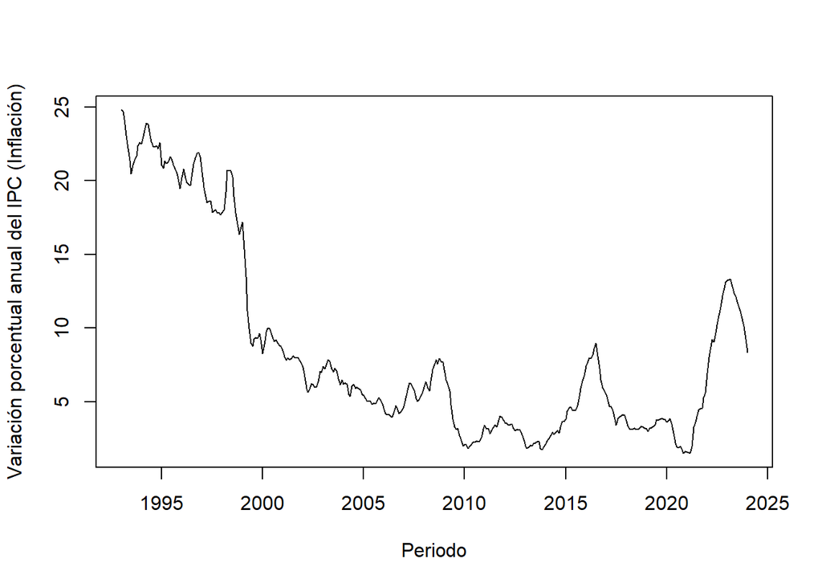

```r
datos <- data.frame(
  Fecha = seq(as.Date("1993-01-01"), by = "month", length.out = 373),
  Valor = rev(datos_inflacion$Inflación)
  )



inflacion <- ts(datos$Valor, start = c(year(datos$Fecha[1]), month(datos$Fecha[1])), frequency = 12)

plot(inflacion, ylab="Variación porcentual anual del IPC (Inflación)", xlab="Periodo")
```

# Estabilización de la Varianza

A continuación se calculará diferentes lambdas para la transformación:

- Lambda1: Metodo loglik
- Lambda2: Guerrero
- Lambda3: Por intervalo

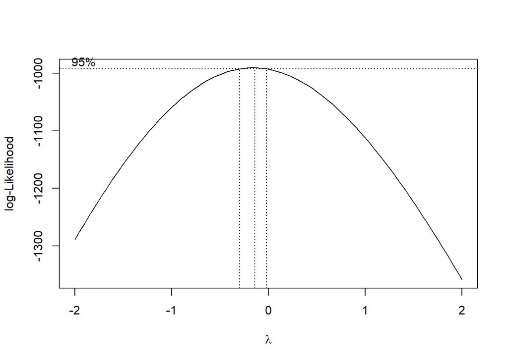

```r
library(MASS)

Lamda1= forecast::BoxCox.lambda(inflacion, method ="loglik", lower = -1, upper = 3)
Lamda2= forecast::BoxCox.lambda(inflacion, method ="guerrero", lower = -1, upper = 4)



resultado_boxcox <- boxcox(lm(inflacion ~ 1))
```

```r
Lamda3<- resultado_boxcox$x[which.max(resultado_boxcox$y)]
```

Los resultados son:

- Lambda1=0
- Lambda2=0.7433729
- Lambda3=-0.1414141

Comparación gráfica de la estabilización de la varianza con distintos $\lambda$s.

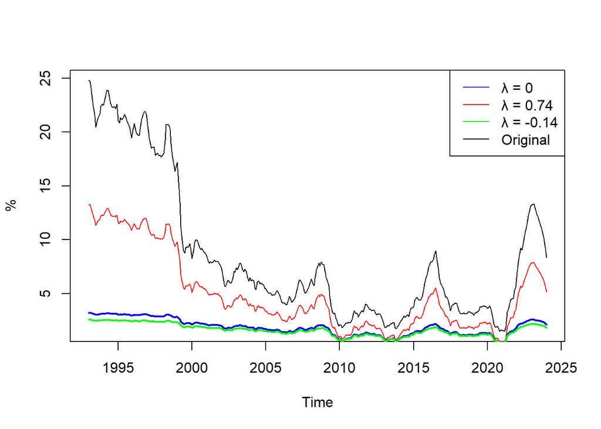

```r
graf1=forecast::BoxCox(inflacion,lambda=Lamda1)
graf2=forecast::BoxCox(inflacion,lambda=Lamda2)
graf3=forecast::BoxCox(inflacion,lambda=Lamda3)

vinflacion=graf1

plot(inflacion, ylab="%")
lines(graf2, col="red")
lines(graf1, lwd=2, col="blue")
lines(graf3,lwd=2, col="green")
legend("topright", legend = c("λ = 0", "λ = 0.74","λ = -0.14", "Original"), col = c("blue", "red","green", "black"), lty = 1)
```

Observemos que la transformación que estabiliza mejor la varianza es precisamente cuando $\lambda=-0.14$. Sin embargo la gráfica azul y la verde no se diferencia mucho, entonces por velocidad de computo vamos a escoger $\lambda=0$.

# Análisis de la tendencia y su correspondiente eliminación.

## Apliquemos diferencia ordinaria :

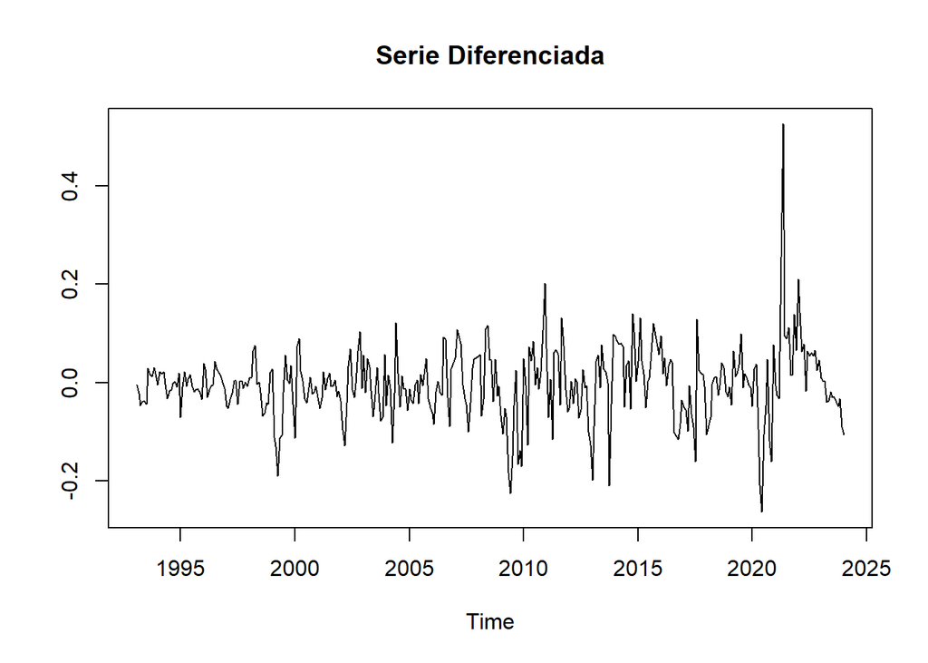

```r
dx=diff(vinflacion)
plot.ts(dx, main="Serie Diferenciada", ylab='')
```

Ahora suavisamiento por kernel.

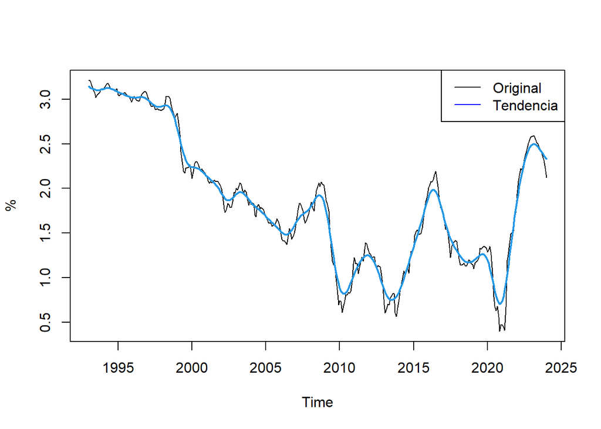

```r
plot(vinflacion, ylab="%")
lines(ksmooth(time(vinflacion), vinflacion, "normal", bandwidth=1), lwd=2, col=4) # el normal
legend("topright", legend = c("Original", "Tendencia"), col = c("black", "blue"), lty = 1)
```

Nota: En la anterior gráfica la serie original hace referencia a la serie con varianza estabilizada.

Ahora quitemos la tendencia:

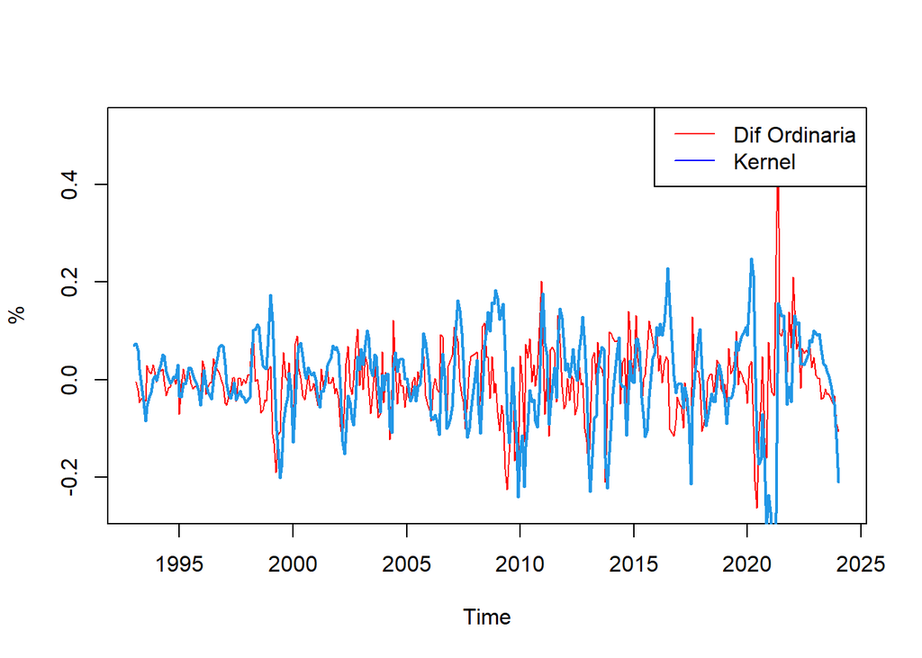

```r
tendencia=ksmooth(time(vinflacion), vinflacion, "normal", bandwidth=1)

t_v_inflacion=vinflacion - tendencia$y

ker_vinflacion=t_v_inflacion
dif_vinflacion=dx


plot(dx, ylab="%", col="red")
lines(t_v_inflacion, lwd=2, col=4) # el normal
legend("topright", legend = c("Dif Ordinaria", "Kernel"), col = c("red", "blue"), lty = 1)
```

A continuación se estudiará la estacionalidad de las dos series suavizadas usando los dos métodos por separado.

### ACF

Ahora veamos la función de auto-correlación pero solo veremos los lags de 1 a 36 meses, ya que un periodo más grande carecen de sentido practico:

Kernel:

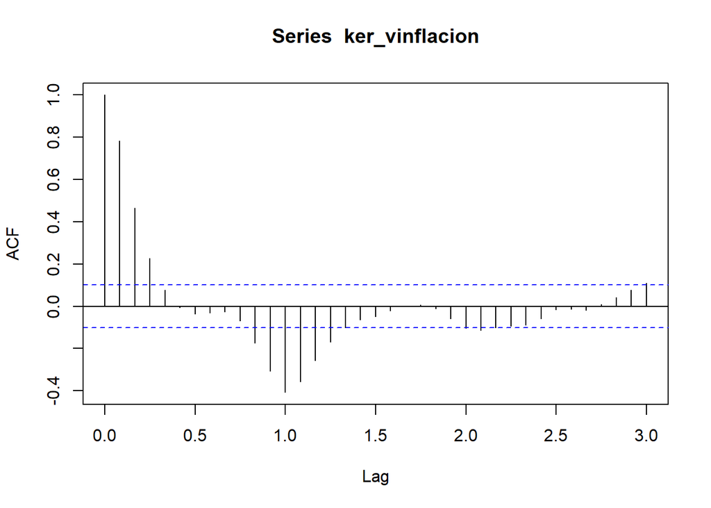

```r
acf(ker_vinflacion,ci = 0.95,ci.type = "white",lag.max = 36)
```

Observamos correlación lineal entre los lags 1 y cuando el lag es de 12 meses.

Diferencia ordinaria:

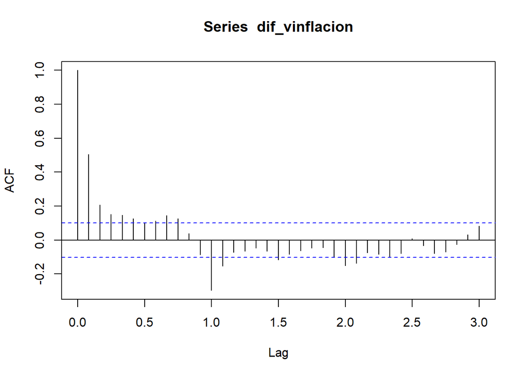

```r
acf(dif_vinflacion,ci = 0.95,ci.type = "white",lag.max =36)
```

En este caso también observamos una correlación baja pero a tener en cuenta en el lag 1 y 12.

### PACF

Kernel:

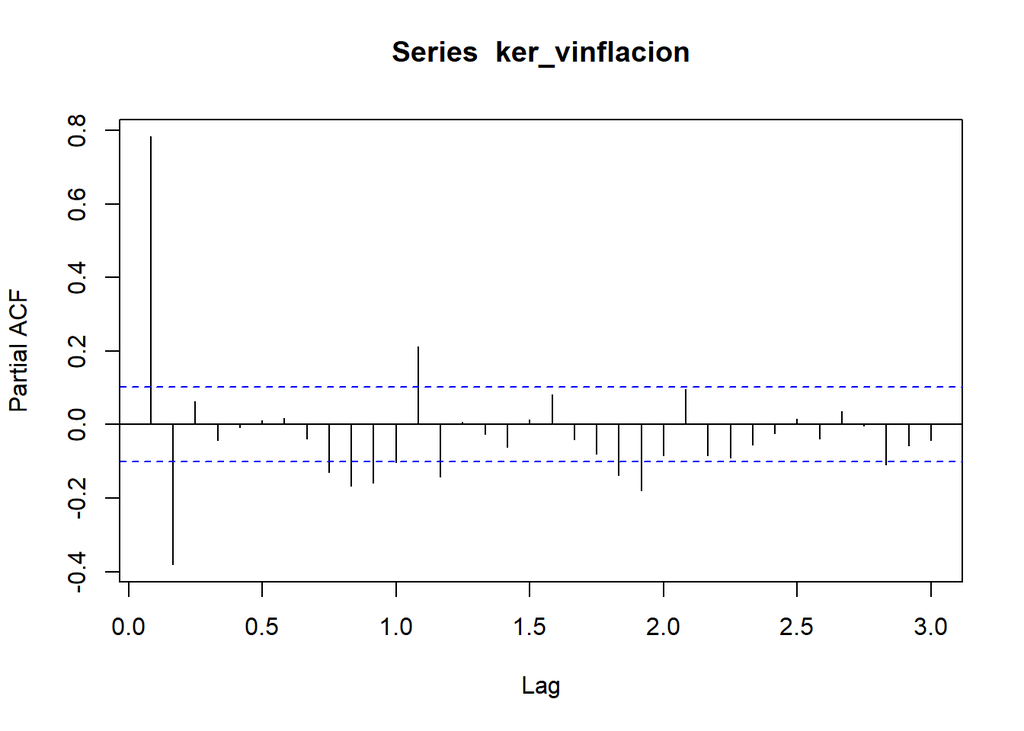

```r
pacf(ker_vinflacion,ci = 0.95,ci.type = "white",lag.max = 36)
```

Aquí como en la anterior vemos una correlación parcial en el lag 1.

Diferencia ordinaria:

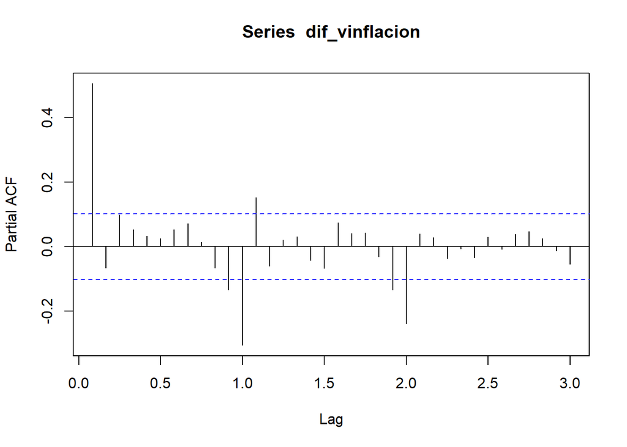

```r
pacf(dif_vinflacion,ci = 0.95,ci.type = "white",lag.max = 36)
```

Aquí observamos una correlación parcial en el lag 12.

## Gráficas de regresión

### Gráficas de regresión usando base de datos con Kernel

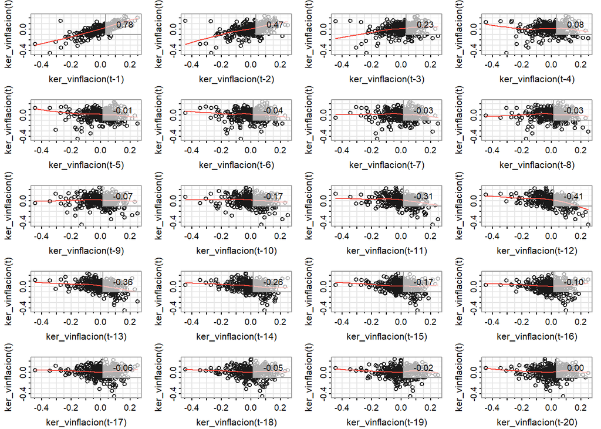

```r
astsa::lag1.plot(ker_vinflacion, 20)
```

En las anteriores gráficas observamos que hay una relación directa entre los meses con lag 1, esto quiere decir que si en un mes la inflación es alta el siguiente mes también será alta. Además en el lag 12 observamos una relación inversa y considerable (40%) esto quiere decir que si en un mes de determinado año la inflación es alta, en el mismo mes del próximo año la inflación bajará, esto ultimo puede ser explicado a que el banco de la república toma medidas para estabilizar la inflación.

### Gráficas de regresión usando base de datos con diferencia ordinaria

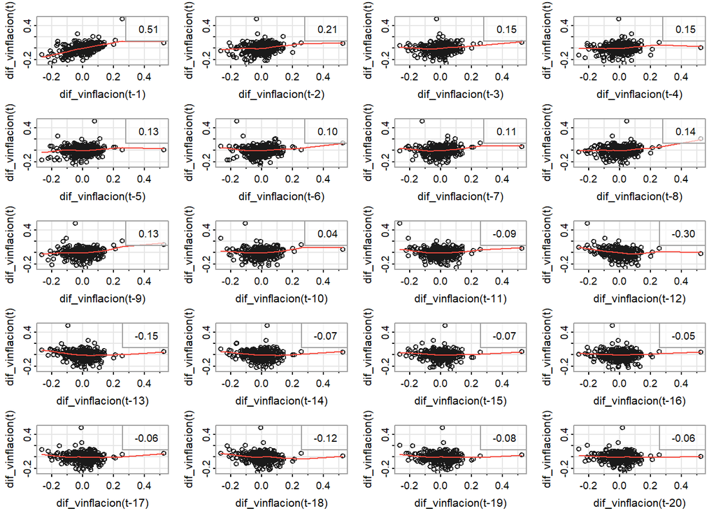

```r
astsa::lag1.plot(dif_vinflacion, 20)
```

en esta no vemos una relación tan alta como en la anterior. Pero es similar.

# Indice AMI

### Indice AMI: Kernel

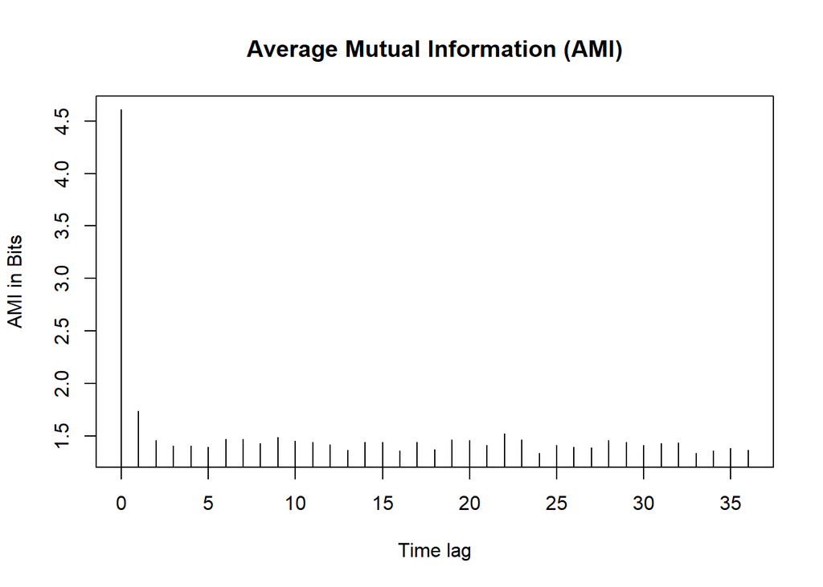

```r
g=nonlinearTseries::mutualInformation(ker_vinflacion,lag.max = 36,n.partitions = 50,units = "Bits",do.plot = TRUE)
```

### Indice AMI: Diferencias ordinarias

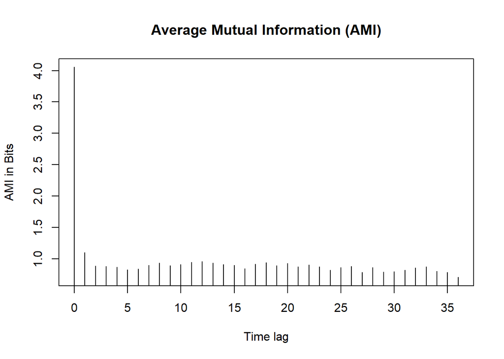

```r
G=nonlinearTseries::mutualInformation(dif_vinflacion,lag.max = 36,n.partitions = 50,units = "Bits",do.plot = TRUE)
```

veamos que en el indice de AMI no muestra patrón de correlaciones.

# Estacionalidad

### Periodograma de kernel:

```r
Periodgrama_ker_vinflacion=spectrum(as.numeric(ker_vinflacion))
```

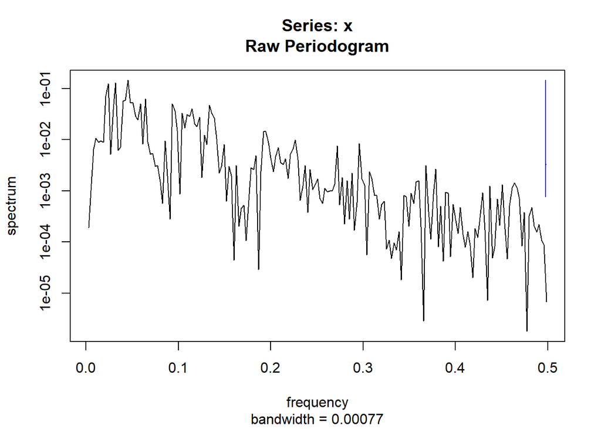

### Periodograma de la diferencia ordinaria:

```r
Periodgrama_def_vinflacion=spectrum(as.numeric(dif_vinflacion))
```

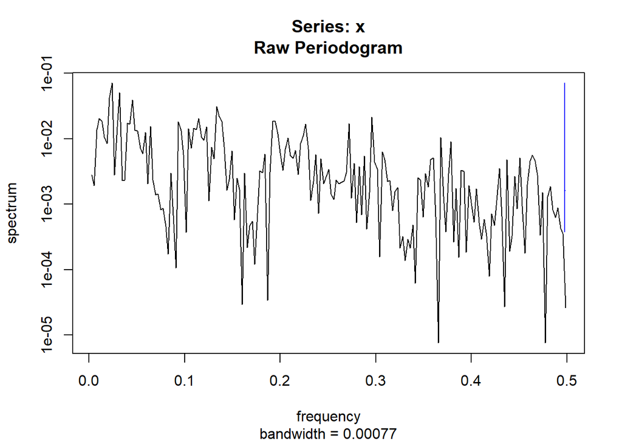

Observemos que el periodograma usando la suavización de diferencias ordinarias o por Kerne no muestran ninguna frecuencia representativa.

Sin embargo observemos los datos suavizados con diferentes frecuencias con la suavización del Kernel, debido a que esta suavización no penaliza tanto a la estacionalidad en comparación con las diferencia ordinarias:

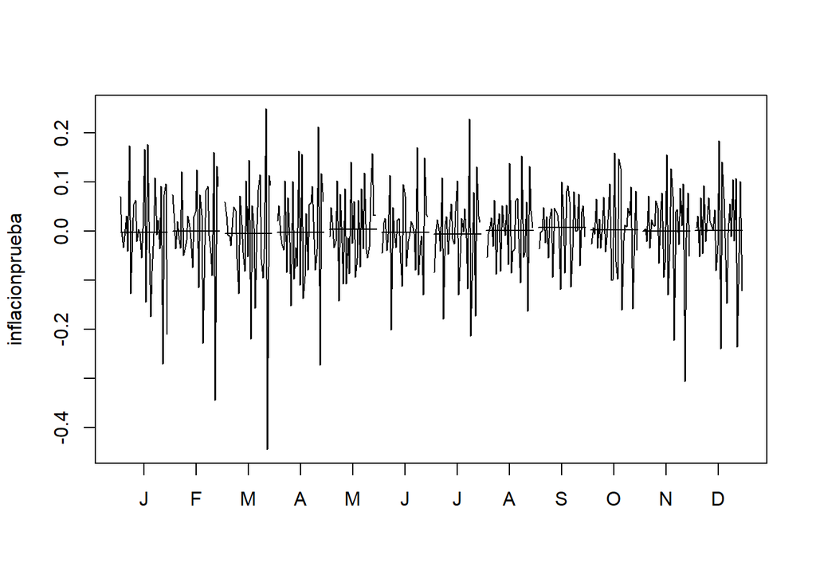

```r
# mensual cada año
inflacionprueba <- ts(ker_vinflacion, frequency =12)
monthplot(inflacionprueba)
```

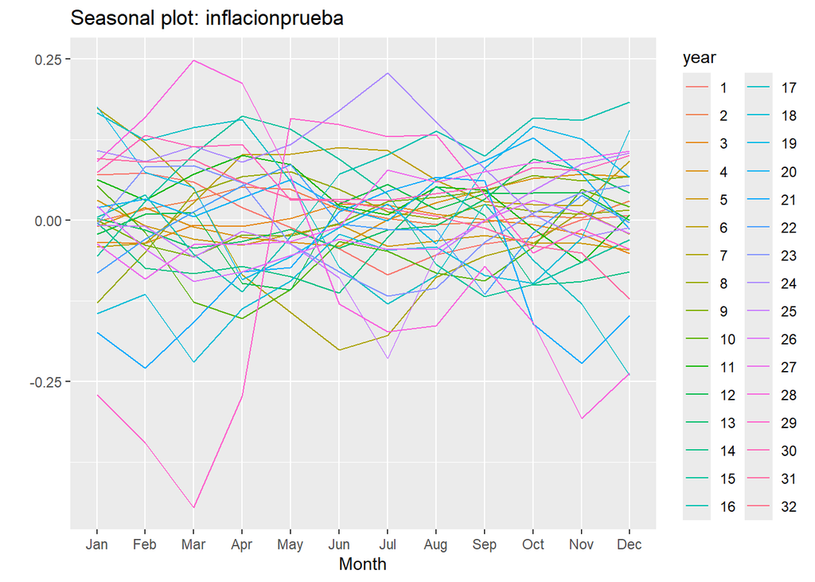

```r
ggseasonplot(inflacionprueba)
```

Observemos que no hay estacionalidad en la serie.

Dado que la serie no presenta estacionalidad entonces podemos pasar de inmediato a un suavizado exponencial para predecir.

# Suavizado exponencial:

Dado que al hacer el box-cox se realizó con $\lambda=0$ y como presenciamos tendencia pero no estacionalidad entonces debemos realizar el suavizado con gamma=FALSE. Entonces se realizará un rolling de un paso adelante y testearlo con los últimos 36 datos (últimos 3 años):

Separemos en datos de prueba y test

```r
n=length(vinflacion)


test=tail(inflacion,36)
```

hagamos el rolling un paso adelante

```r
pronosticos=c()
```

```r
for (i in 1:36){
  k=n-37+i
  HWAP_inic=stats::HoltWinters(vinflacion[1:k],alpha=NULL,beta=NULL,gamma=FALSE)
  pronostico=as.list(forecast::forecast(HWAP_inic,h=1,level =0.95,lambda = 0)$mean[1])$fit
  pronosticos=c(pronosticos,pronostico)
}
```

[output not shown]

[output cut: 52 more lines]

[output not shown]

```r
pronosticos
```

```
##  [1]  1.550587  1.514979  1.464794  2.092390  4.746339  4.409385  4.621806
##  [8]  5.092015  4.944026  4.871415  5.763304  6.100585  7.897054  9.163085
## [15]  9.506652 10.177736  9.586988 10.254592 10.809815 11.488576 12.105702
## [22] 12.975540 13.136106 13.748470 13.698046 13.572667 13.546648 12.752591
## [29] 12.149547 11.916163 11.522155 11.145945 10.659972 10.099980  9.800254
## [36]  8.776985
```

Calculemos el error cuadratico medio

```r
# Paso 1: Calcular los residuos
residuos <- test- pronosticos

# Paso 2: Cuadrar los residuos
residuos_cuadrados <- residuos^2

# Paso 3: Calcular el ECM
ecm <- mean(residuos_cuadrados)

# Imprimir el resultado
print(ecm)
```

```
## [1] 0.2264962
```

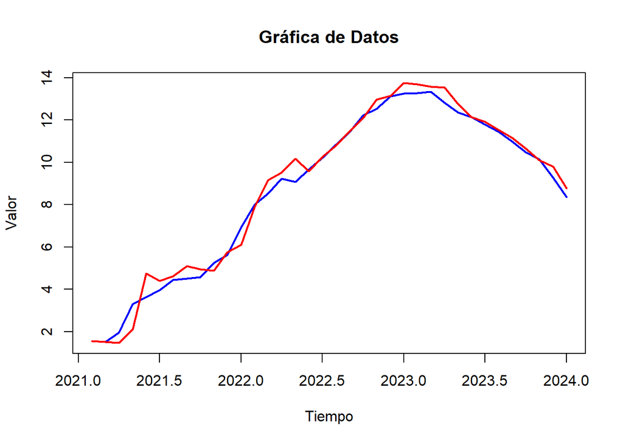

```r
# Graficar ts_data
plot(test, type = "l", col = "blue", lwd = 2, ylim = range(c(test, pronosticos)),xlab = "Tiempo", ylab = "Valor", main = "Gráfica de Datos")
lines(time(test)[1:length(pronosticos)],pronosticos, col = "red", lwd = 2)
```

# Arboles de decisión

#### HiperParametros:

- Lags
- Profundidad maxima

A continuación se realizará un modelado usando arboles decisión que pronostique un paso adelante, primero observemos que los datos que se usaran para entrenar (1993-2020) están en un rango de 2 a 25 y los datos para el test están contenidos en este rango, esto quiere decir que el modelo de arboles no estaría limitado por el conjunto de entrenamiento.

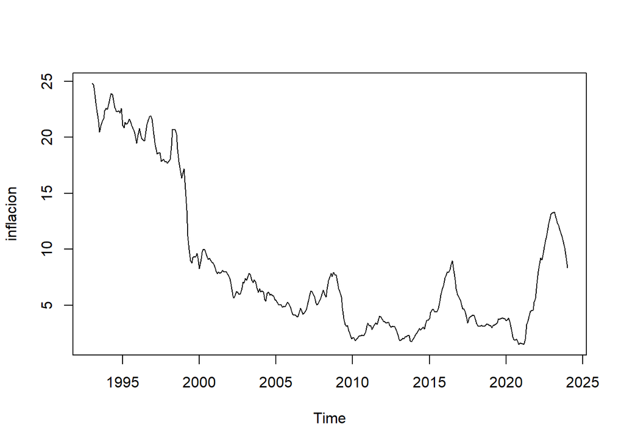

```r
plot(inflacion )
```

Paso intermedio para pasar la serie de tiempo a Python:

```r
library(reticulate)
inflacion_df <- data.frame(fecha= time(inflacion), data= as.numeric(inflacion))


#Pasamos a python
inflacion_df_py <- r_to_py(inflacion_df )
```

```python
import pandas as pd

# Convertir el objeto rpy2 a pandas DataFrame
inflacion_pd = r.inflacion_df_py

dates = pd.date_range(start='1993-01-01', end='2024-01-01', freq='MS')

inflacion_pd.fecha=dates

# Mostrar las primeras filas del DataFrame
inflacion_pd.head()
```

```
##        fecha   data
## 0 1993-01-01  24.82
## 1 1993-02-01  24.71
## 2 1993-03-01  24.18
## 3 1993-04-01  23.08
## 4 1993-05-01  22.21
```

Seguimos ahora a usar Python para el modelos de arboles de decisión:

```python
#librerias

# Data manipulation
# ==============================================================================
import numpy as np
import pandas as pd

# Plots
# ==============================================================================
import matplotlib.pyplot as plt
plt.style.use('fivethirtyeight')
plt.rcParams['lines.linewidth'] = 1.5
plt.rcParams['font.size'] = 10

# Modeling and Forecasting
# ==============================================================================
from sklearn.linear_model import LinearRegression
from sklearn.linear_model import Lasso
from sklearn.ensemble import RandomForestRegressor
from sklearn.metrics import mean_squared_error
from sklearn.metrics import mean_absolute_error
from sklearn.preprocessing import StandardScaler
from sklearn.tree import DecisionTreeRegressor

from skforecast.ForecasterAutoreg import ForecasterAutoreg
from skforecast.ForecasterAutoregCustom import ForecasterAutoregCustom
from skforecast.ForecasterAutoregDirect import ForecasterAutoregDirect
from skforecast.model_selection import grid_search_forecaster
from skforecast.model_selection import backtesting_forecaster
from skforecast.utils import save_forecaster
from skforecast.utils import load_forecaster

# Warnings configuration
# ==============================================================================
import warnings
# warnings.filterwarnings('ignore')
```

Para mas información visitar [Link](https://cienciadedatos.net/documentos/py27-forecasting-series-temporales-python-scikitlearn.html)

```python
# Configurar la columna 'Fecha' como índice del DataFrame
inflacion_pd = inflacion_pd.set_index('fecha')

# Ajustar la frecuencia de la serie temporal a mensual
inflacion_pd = inflacion_pd.asfreq('MS')

# Renombrar la columna 'lluvia' a 'yprecip'
inflacion_pd = inflacion_pd.rename(columns={'data':'yprecip'})

# Mostrar las primeras filas del DataFrame
inflacion_pd.head()
```

```
##             yprecip
## fecha
## 1993-01-01    24.82
## 1993-02-01    24.71
## 1993-03-01    24.18
## 1993-04-01    23.08
## 1993-05-01    22.21
```

Verifiquemos que tengamos todos los datos:

```python
print(f'Numero de filas con valores faltantes: {inflacion_pd.isnull().any(axis=1).mean()}')
```

```
## Numero de filas con valores faltantes: 0.0
```

Vamos a establecer que los últimos 3 años (36 meses) sean usando para medir la capacidad predictiva

```python
steps = 36

#Dado  que quiero que sean anos completo, voy a quitar el ultimo registro, el cual #es el primer mes del 2024

#ker_vinflacion_pd = ker_vinflacion_pd.iloc[:-1]

data_train = inflacion_pd[:-steps]
data_test  = inflacion_pd[-steps:]

print(f"Train dates : {data_train.index.min()} --- {data_train.index.max()}  (n={len(data_train)})")
```

```
## Train dates : 1993-01-01 00:00:00 --- 2021-01-01 00:00:00  (n=337)
```

```python
print(f"Test dates  : {data_test.index.min()} --- {data_test.index.max()}  (n={len(data_test)})")
```

```
## Test dates  : 2021-02-01 00:00:00 --- 2024-01-01 00:00:00  (n=36)
```

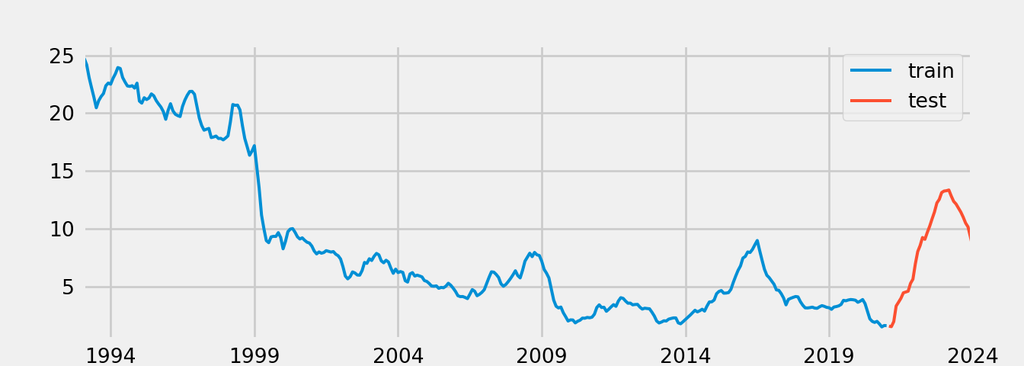

```python
fig, ax = plt.subplots(figsize=(7, 2.5))
data_train['yprecip'].plot(ax=ax, label='train')
data_test['yprecip'].plot(ax=ax, label='test')
ax.legend();
```

Vamos a crear un modelos a través de la clase ForecasterAutoreg, el cual es entrenado usando DecisionTreeRegressor.

## Clase ForecasterAutoreg:

Ver como se entrena el modelo: [Link](https://cienciadedatos.net/documentos/py27-forecasting-series-temporales-python-scikitlearn.html)

### Hallar hiperparametros optimos:

A continación se realizará un modelo que prediga un mese adelante, se usará la clase ForecasterAutoreg. Primeramente vamos a buscar la mejor combinación de retardos e hiperparámetros del modelo de árboles por medio de la función grid_search_forecaster. También hace random search y Bayesian search. Se hace Backtesting para validar la capacidad predictiva que tienen los modelos bajo los hiperparámetros propuestos. Se puede hacer validación cruzada o la tradicional entrenamiento y prueba. En este ejemplo se hace validación cruzada secuencial. Vale la pena recordar que validación cruzada se hace sobre el mismo conjunto de entrenamiento, lo cual es diferente al caso de tener un conjunto de validación. Pero en el caso de tener conjunto de validación se debe tener en cuenta, por favor chequear https://skforecast.org/0.4.3/notebooks/prediction-intervals.html y debe incorporarse el conjunto de validación al de entrenamiento.

```python
#verificar que lso datos tengan frecuencia mensual y las fechas esten bien
print(data_train.index)
```

```
## DatetimeIndex(['1993-01-01', '1993-02-01', '1993-03-01', '1993-04-01',
##                '1993-05-01', '1993-06-01', '1993-07-01', '1993-08-01',
##                '1993-09-01', '1993-10-01',
##                ...
##                '2020-04-01', '2020-05-01', '2020-06-01', '2020-07-01',
##                '2020-08-01', '2020-09-01', '2020-10-01', '2020-11-01',
##                '2020-12-01', '2021-01-01'],
##               dtype='datetime64[ns]', name='fecha', length=337, freq='MS')
```

```python
print(data_train['yprecip'].index)
```

```
## DatetimeIndex(['1993-01-01', '1993-02-01', '1993-03-01', '1993-04-01',
##                '1993-05-01', '1993-06-01', '1993-07-01', '1993-08-01',
##                '1993-09-01', '1993-10-01',
##                ...
##                '2020-04-01', '2020-05-01', '2020-06-01', '2020-07-01',
##                '2020-08-01', '2020-09-01', '2020-10-01', '2020-11-01',
##                '2020-12-01', '2021-01-01'],
##               dtype='datetime64[ns]', name='fecha', length=337, freq='MS')
```

```python
import warnings


warnings.simplefilter('ignore'
) #para ignorar advertencia de sobrecomputo
# Hyperparameter Grid search
# ==============================================================================
steps = 1 #paso a predecir
forecaster = ForecasterAutoreg(
                regressor = DecisionTreeRegressor(random_state= 0),
                lags      = 2 # This value will be replaced in the grid search
             )

# Lags used as predictors
lags_grid = [3,5,6,7]

# Regressor's hyperparameters
param_grid = { 'max_depth': [1,2,3,4,5,6,7,8,9,10]}

results_grid = grid_search_forecaster(
                        forecaster         = forecaster,
                        y                  = data_train['yprecip'],
                        param_grid         = param_grid,
                        lags_grid          = lags_grid,
                        steps              = steps,
                        refit              = True,
                        metric             = 'mean_squared_error',
                        initial_train_size = int(len(data_train)*0.5),
                        fixed_train_size   = False,
                        return_best        = True,
                        verbose            = False #TRue  para mostrar todo el proceso
               )
```

```
## Number of models compared: 40.
##
##
##
##
##
##
##
##
##
##
##
##
##

lags grid:  25%|##5       | 1/4 [00:07<00:22,  7.41s/it]
lags grid:  75%|#######5  | 3/4 [00:14<00:04,  4.56s/it]
## `Forecaster` refitted using the best-found lags and parameters, and the whole data set:
##   Lags: [1 2 3 4 5]
##   Parameters: {'max_depth': 8}
##   Backtesting metric: 0.15480028342339644
```

La conclusión es que el mejor, son los lags hasta 5 y una profundidad máxima de 8:

```python
# Grid Search results
# ==============================================================================
results_grid
```

```
##                      lags             lags_label  ... mean_squared_error  max_depth
## 17        [1, 2, 3, 4, 5]        [1, 2, 3, 4, 5]  ...           0.154800          8
## 19        [1, 2, 3, 4, 5]        [1, 2, 3, 4, 5]  ...           0.158306         10
## 14        [1, 2, 3, 4, 5]        [1, 2, 3, 4, 5]  ...           0.160095          5
## 38  [1, 2, 3, 4, 5, 6, 7]  [1, 2, 3, 4, 5, 6, 7]  ...           0.161245          9
## 16        [1, 2, 3, 4, 5]        [1, 2, 3, 4, 5]  ...           0.162596          7
## 28     [1, 2, 3, 4, 5, 6]     [1, 2, 3, 4, 5, 6]  ...           0.163185          9
## 18        [1, 2, 3, 4, 5]        [1, 2, 3, 4, 5]  ...           0.167580          9
## 27     [1, 2, 3, 4, 5, 6]     [1, 2, 3, 4, 5, 6]  ...           0.168109          8
## 5               [1, 2, 3]              [1, 2, 3]  ...           0.168449          6
## 36  [1, 2, 3, 4, 5, 6, 7]  [1, 2, 3, 4, 5, 6, 7]  ...           0.169540          7
## 37  [1, 2, 3, 4, 5, 6, 7]  [1, 2, 3, 4, 5, 6, 7]  ...           0.169725          8
## 26     [1, 2, 3, 4, 5, 6]     [1, 2, 3, 4, 5, 6]  ...           0.170489          7
## 35  [1, 2, 3, 4, 5, 6, 7]  [1, 2, 3, 4, 5, 6, 7]  ...           0.170553          6
## 15        [1, 2, 3, 4, 5]        [1, 2, 3, 4, 5]  ...           0.172125          6
```

[output cut: 28 more lines]

### Modelo Final

```python
# Create and train forecaster with the best hyperparameters
# ==============================================================================
max_depth=8
lags=5

regressor = DecisionTreeRegressor(max_depth=max_depth)


forecaster = ForecasterAutoreg(
                regressor = regressor,
                lags      = lags
             )

forecaster.fit(y=data_train['yprecip'])

Final_Forecaster=forecaster
```

```python
datos_prueba=data_train[-lags:]
prueba=pd.concat([datos_prueba,data_test],axis=0) #concateno lo ultimo 5 datos de entrenamiento y se los coloco a los de prueba
```

```python
predic=[]  #Predicciones un paso adelante con los datos de prueba
for i in range(len(prueba)-lags):
  predic.append(forecaster.predict(steps=1, last_window=prueba['yprecip'][0+i:5+i])[0] )

print(len(predic))
```

```
## 36
```

```python
origin=[]
for j in range(len(data_test['yprecip']) ):
  origin.append(data_test['yprecip'][j])
print(origin)
```

```
## [1.56, 1.51, 1.95, 3.3, 3.63, 3.97, 4.44, 4.51, 4.58, 5.26, 5.62, 6.94, 8.01, 8.53, 9.23, 9.07, 9.67, 10.21, 10.84, 11.44, 12.22, 12.53, 13.12, 13.25, 13.28, 13.34, 12.82, 12.36, 12.13, 11.78, 11.43, 10.99, 10.48, 10.15, 9.28, 8.35]
```

## Error:

```python
#Riesgo empirico
import sklearn.metrics
sklearn.metrics.root_mean_squared_error( predic, origin )
```

```
## 1.64955446402474
```

predecir datos de entrenamiento y validación

```python
predic_train_val=[]  #Predicciones un paso adelante con los datos de prueba
for i in range(len(data_train)-lags):
  predic_train_val.append(forecaster.predict(steps=1, last_window=data_train['yprecip'][0+i:5+i])[0] )

print(len(predic_train_val))
```

```
## 332
```

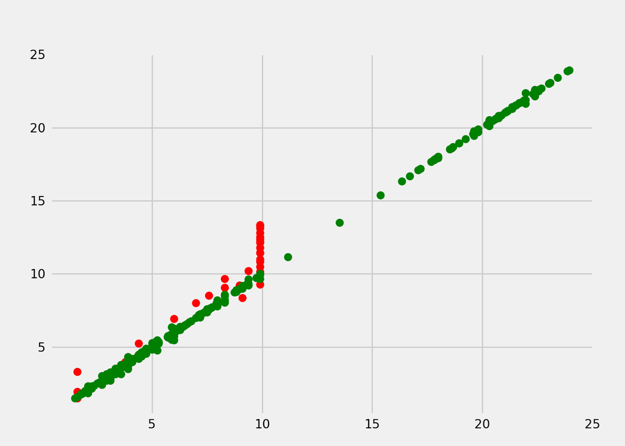

```python
# Plot predicted against actual values but with train + val




plt.close('all')

from matplotlib import pyplot as plt


plt.scatter( predic, origin, label='test', c="red")  # red (ejex predicción, ejey valor reaal de los datos de prueba )

plt.scatter( predic_train_val, data_train[5:], label='test', c="green") # green (ejex predicción de los datos de entrenamiento y validacion, ejey valor reaal de los datos de entreanmiento y validacion )


plt.show()
```

Nota para el autor: el hecho de que los puntos rojos tenga valores en el ejey menores se debe a que gráficamente la inflación en los últimos años no es tan alta como a inicios de gráfica.

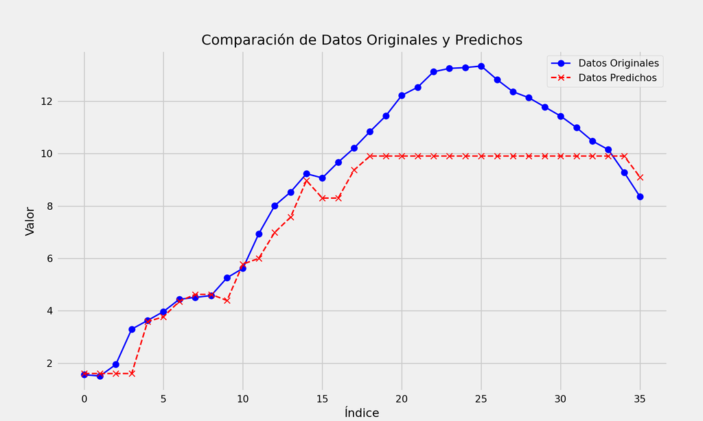

```python
# Crear la gráfica
plt.figure(figsize=(10, 6))

# Graficar los datos originales
plt.plot(origin, color='blue', label='Datos Originales', marker='o')

# Graficar los datos predichos
plt.plot(predic, color='red', label='Datos Predichos', linestyle='--', marker='x')

# Etiquetas y título
plt.xlabel('Índice')
plt.ylabel('Valor')
plt.title('Comparación de Datos Originales y Predichos')

# Leyenda
plt.legend()

# Mostrar la gráfica
plt.grid(True)
plt.show()
```

# Redes neuronales multicapa

Hiperparametros:

- # neuronas
- Epocas
- Función de activación

Nota: dado que nuestra serie no tiene estacionalidad entonces no usamos variables de series de furier y vamos a usar los mismos datos de test que en arboles de decisión.

### Creación de variables rezagadas

```python
from pandas import DataFrame
# reframe as supervised learning
# lag observation (t-1) is the input variable and t is the output variable.
df1 = DataFrame()
print(df1)
```

```
## Empty DataFrame
## Columns: []
## Index: []
```

```python
for i in range(5,0,-1):
    df1[['t-'+str(i)]] = inflacion_pd.shift(i)
```

```python
print(df1) #retardos a considerar
```

```
##               t-5    t-4    t-3    t-2    t-1
## fecha
## 1993-01-01    NaN    NaN    NaN    NaN    NaN
## 1993-02-01    NaN    NaN    NaN    NaN  24.82
## 1993-03-01    NaN    NaN    NaN  24.82  24.71
## 1993-04-01    NaN    NaN  24.82  24.71  24.18
## 1993-05-01    NaN  24.82  24.71  24.18  23.08
## ...           ...    ...    ...    ...    ...
## 2023-09-01  12.82  12.36  12.13  11.78  11.43
## 2023-10-01  12.36  12.13  11.78  11.43  10.99
## 2023-11-01  12.13  11.78  11.43  10.99  10.48
## 2023-12-01  11.78  11.43  10.99  10.48  10.15
## 2024-01-01  11.43  10.99  10.48  10.15   9.28
##
## [373 rows x 5 columns]
```

```python
# Create column t
df1['t'] = inflacion_pd.values
print(df1.head(8))
```

```
##               t-5    t-4    t-3    t-2    t-1      t
## fecha
## 1993-01-01    NaN    NaN    NaN    NaN    NaN  24.82
## 1993-02-01    NaN    NaN    NaN    NaN  24.82  24.71
## 1993-03-01    NaN    NaN    NaN  24.82  24.71  24.18
## 1993-04-01    NaN    NaN  24.82  24.71  24.18  23.08
## 1993-05-01    NaN  24.82  24.71  24.18  23.08  22.21
## 1993-06-01  24.82  24.71  24.18  23.08  22.21  21.38
## 1993-07-01  24.71  24.18  23.08  22.21  21.38  20.46
## 1993-08-01  24.18  23.08  22.21  21.38  20.46  21.07
```

```python
# Create a new subsetted dataframe, removing Nans from first 7 rows
df1_infl = df1[5:]
print(df1_infl.head(5))
```

```
##               t-5    t-4    t-3    t-2    t-1      t
## fecha
## 1993-06-01  24.82  24.71  24.18  23.08  22.21  21.38
## 1993-07-01  24.71  24.18  23.08  22.21  21.38  20.46
## 1993-08-01  24.18  23.08  22.21  21.38  20.46  21.07
## 1993-09-01  23.08  22.21  21.38  20.46  21.07  21.43
## 1993-10-01  22.21  21.38  20.46  21.07  21.43  21.69
```

```python
df1_infl.shape
```

```
## (368, 6)
```

```python
# Split data

PRESsplit = df1_infl.values
# split into lagged variables and original time series
X1= PRESsplit[:, 0:-1]  # slice all rows and start with column 0 and go up to but not including the last column
y1 =PRESsplit[:,-1]  # slice all rows and last column, essentially separating out 't' column
```

```python
# Separar los últimos 36 datos para el conjunto de prueba
test_size = 36
X_train, X_test = X1[:-test_size], X1[-test_size:]
y_train, y_test = y1[:-test_size], y1[-test_size:]
```

```python
print(X_train.shape)
```

```
## (332, 5)
```

```python
print(y_train.shape)
```

```
## (332,)
```

```python
print(X_test.shape)
```

```
## (36, 5)
```

```python
print(y_test.shape)
```

```
## (36,)
```

Normalicemos

```python
from sklearn.preprocessing import StandardScaler

# Crear el scaler
scaler = StandardScaler()

# Ajustar y transformar los datos de entrenamiento
X_train_scaled = scaler.fit_transform(X_train)

# Solo transformar los datos de prueba
X_test_scaled = scaler.transform(X_test)

X_train=X_train_scaled
X_test=X_test_scaled
```

### Modelo

se realizó una validación criuzada para calcular los hiperparametros, los cuales fueron como resultados:

- Neuronas: Capa1=20 , Capa2=15
- Epocas=50
- Función de activación= relu

```python
import tensorflow as tf
import numpy as np
import random

# Fijar las semillas para reproducibilidad
seed_value = 42
np.random.seed(seed_value)
tf.random.set_seed(seed_value)
random.seed(seed_value)

from tensorflow.keras.models import Sequential
from tensorflow.keras.layers import Dense
from sklearn.metrics import mean_squared_error

from tensorflow.keras.callbacks import EarlyStopping
from sklearn.model_selection import GridSearchCV, TimeSeriesSplit


def create_model(neurons_layer1, neurons_layer2, activation):
    model = Sequential()
    model.add(Dense(neurons_layer1, input_dim=X_train.shape[1], activation=activation))
    model.add(Dense(neurons_layer2, activation=activation))
    model.add(Dense(1))  # Capa de salida para regresión
    model.compile(optimizer='adam', loss='mean_squared_error')
    return model
```

```python
# Crear el modelo final con los mejores hiperparámetros
final_model = create_model(neurons_layer1=20, neurons_layer2=15, activation='relu' )

# Entrenar el modelo en todos los datos de entrenamiento
final_model.fit(X_train, y_train, epochs=50, verbose=0)
```

```
## <keras.src.callbacks.history.History object at 0x000001DF5B85E5D0>
```

```python
# Evaluar en el conjunto de prueba
y_pred = final_model.predict(X_test)
```

```
##
## 1/2 ━━━━━━━━━━━━━━━━━━━━ 0s 55ms/step
## 2/2 ━━━━━━━━━━━━━━━━━━━━ 0s 32ms/step
```

```python
final_mse = mean_squared_error(y_test, y_pred)
print(f"MSE en el conjunto de prueba: {final_mse}")
```

```
## MSE en el conjunto de prueba: 1.347671816957183
```

## Error:

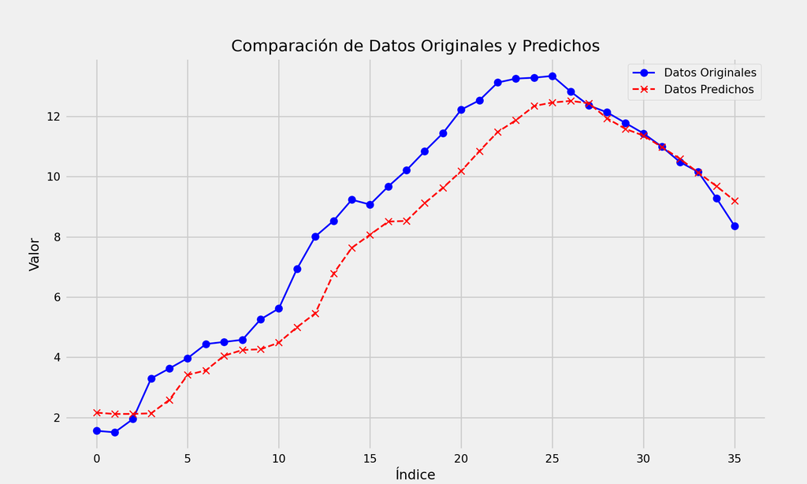

```python
# Crear la gráfica
plt.figure(figsize=(10, 6))

# Graficar los datos originales
plt.plot(y_test, color='blue', label='Datos Originales', marker='o')

# Graficar los datos predichos
plt.plot(y_pred, color='red', label='Datos Predichos', linestyle='--', marker='x')

# Etiquetas y título
plt.xlabel('Índice')
plt.ylabel('Valor')
plt.title('Comparación de Datos Originales y Predichos')

# Leyenda
plt.legend()

# Mostrar la gráfica
plt.grid(True)
plt.show()
```

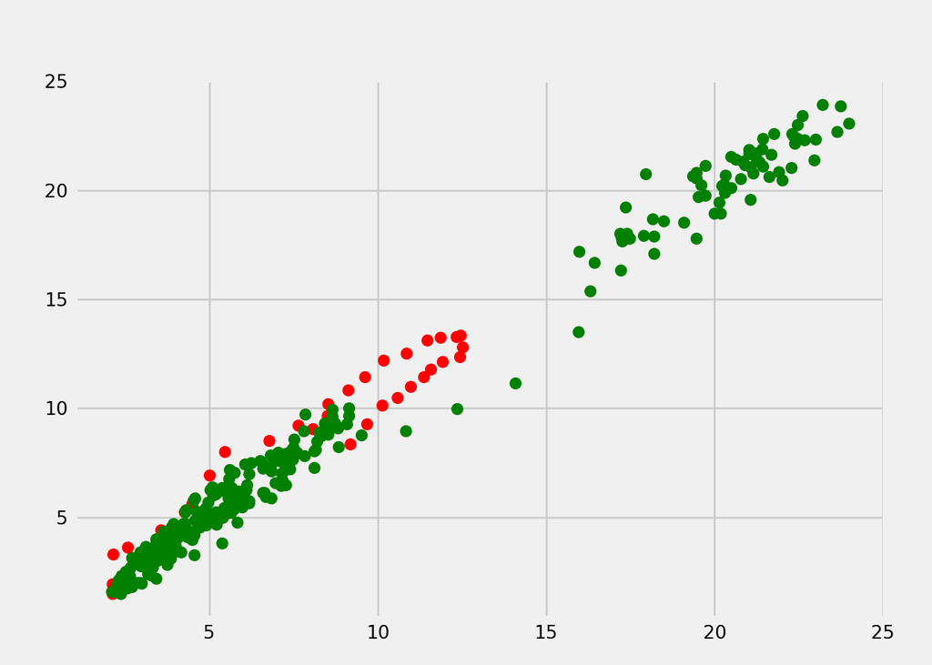

```python
from matplotlib import pyplot as plt

plt.close('all')
plt.scatter(  y_pred , y_test, label='test', c="red")  # red (ejex predicción, ejey valor reaal de los datos de prueba )

plt.scatter( final_model.predict(X_train), y_train, label='test', c="green") # green (ejex predicción de los datos de entrenamiento y validacion, ejey valor reaal de los datos de entreanmiento y validacion )


plt.show()
```

Veamos que el error empírico es menor con redes neuronales que con arboles de decisión.

# Redes neuronales recurrentes RNN

```python
use_features = ['yprecip'] # continuous input
target = ['yprecip'] # continuous output
n_steps_ahead =1 # pasos a predecir
n_steps=5 #lags para predecir
```

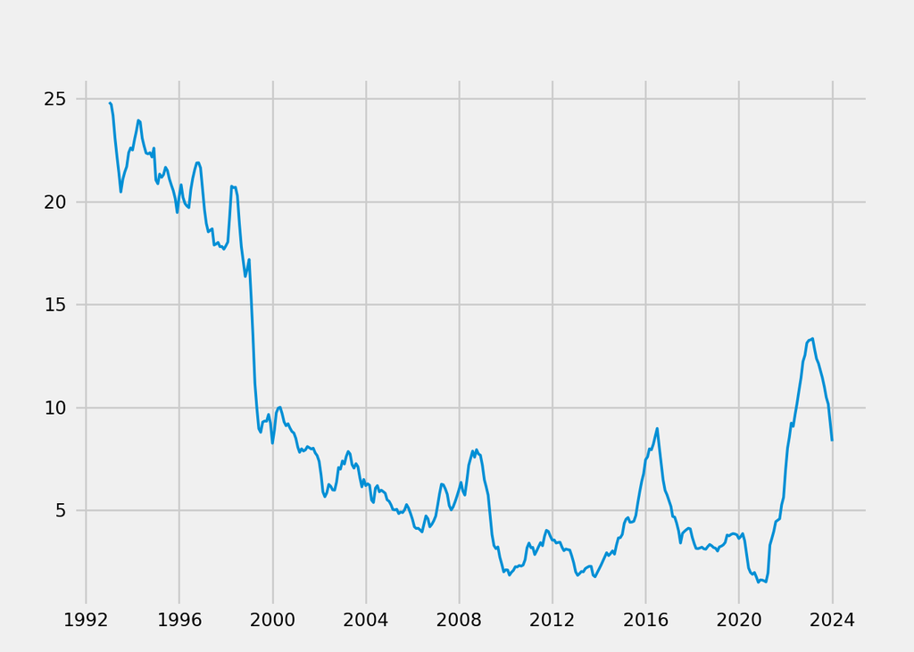

```python
plt.plot(inflacion_pd['yprecip'])
```

Dividir la serie temporal en conjuntos de entrenamiento y prueba

```python
split = 36

df_train = inflacion_pd[use_features].iloc[:-split]
df_test = inflacion_pd[use_features].iloc[-split -n_steps :]

len(df_test)
```

```
## 41
```

Escalar

```python
from sklearn.preprocessing import StandardScaler

# Crear un objeto StandardScaler
scaler = StandardScaler()

# Ajustar el scaler en los datos de entrenamiento y transformar los datos
df_train_scaled = scaler.fit_transform(df_train)

# Solo transformar los datos de prueba (sin ajustar nuevamente)
df_test_scaled = scaler.transform(df_test)

# Convertir los arrays de nuevo a DataFrames para conservar los índices
df_train_scaled = pd.DataFrame(df_train_scaled, index=df_train.index, columns=df_train.columns)
df_test_scaled = pd.DataFrame(df_test_scaled, index=df_test.index, columns=df_test.columns)


df_train=df_train_scaled
df_test=df_test_scaled
```

```python
def get_lagged_features(df, n_steps, n_steps_ahead):
    """
    df: pandas DataFrame of time series to be lagged
    n_steps: number of lags, i.e. sequence length
    n_steps_ahead: forecasting horizon
    """
    lag_list = []

    for lag in range(n_steps + n_steps_ahead - 1, n_steps_ahead - 1, -1):
        lag_list.append(df.shift(lag))
    lag_array = np.dstack([i[n_steps+n_steps_ahead-1:] for i in lag_list])
    # We swap the last two dimensions so each slice along the first dimension
    # is the same shape as the corresponding segment of the input time series
    lag_array = np.swapaxes(lag_array, 1, -1)
    return lag_array
```

```python
x_train = get_lagged_features(df_train, n_steps, n_steps_ahead)
y_train =  df_train.values[n_steps + n_steps_ahead - 1:]
y_train_timestamps = df_train.index[n_steps + n_steps_ahead - 1:]

x_test = get_lagged_features(df_test , n_steps, n_steps_ahead)
y_test =  df_test.values[n_steps + n_steps_ahead-1:]
y_test_timestamps = df_test.index[n_steps + n_steps_ahead  -1:]
```

```python
print([tensor.shape for tensor in (x_train, y_train, x_test, y_test)])
```

```
## [(332, 5, 1), (332, 1), (36, 5, 1), (36, 1)]
```

Observemos que tenemos 36 datos para probar, esto es gracias a lo comentado anteriormente.

```python
def SimpleRNN_(n_units, l1_reg, seed=0):
  #def SimpleRNN_(n_units = 10, seed=0):
  model = keras.models.Sequential()

  model.add(keras.layers.SimpleRNN(n_units, activation='tanh', kernel_initializer=keras.initializers.glorot_uniform(seed), bias_initializer=keras.initializers.glorot_uniform(seed), recurrent_initializer=keras.initializers.orthogonal(seed), kernel_regularizer=keras.regularizers.L1(l1_reg), input_shape=(x_train.shape[1], x_train.shape[-1]), unroll=True, stateful=False))

  model.add(keras.layers.Dense(1, kernel_initializer=keras.initializers.glorot_uniform(seed), bias_initializer=keras.initializers.glorot_uniform(seed), kernel_regularizer=keras.regularizers.L1(l1_reg)))

  model.compile(loss='mean_squared_error', optimizer='adam')
  return model

def LSTM_(n_units, l1_reg, seed=0):
  #def LSTM_(n_units = 10,  seed=0):
  model = keras.models.Sequential()

  model.add(keras.layers.LSTM(n_units, activation='tanh', kernel_initializer=keras.initializers.glorot_uniform(seed), bias_initializer=keras.initializers.glorot_uniform(seed), recurrent_initializer=keras.initializers.orthogonal(seed), kernel_regularizer=keras.regularizers.L1(l1_reg), input_shape=(x_train.shape[1], x_train.shape[-1]), unroll=True))

  model.add(keras.layers.Dense(1, kernel_initializer=keras.initializers.glorot_uniform(seed), bias_initializer=keras.initializers.glorot_uniform(seed), kernel_regularizer=keras.regularizers.L1(l1_reg)))

  model.compile(loss='mean_squared_error', optimizer='adam')
  return model
```

```python
max_epochs = 50 #Dejar mil
batch_size = 500
```

```python
from tensorflow.keras.callbacks import EarlyStopping

es = EarlyStopping(monitor='loss', mode='min', verbose=1, patience=10, min_delta=1e-7, restore_best_weights=True)
```

```python
params = {
  'rnn': {
        'model': None, 'function': SimpleRNN_, 'l1_reg': 0.0, 'H': 20,
        'color': 'blue', 'label':'RNN'},
  'lstm': {
        'model': None, 'function': LSTM_,'l1_reg': 0.0, 'H': 10,
        'color':'red', 'label': 'LSTM'}
}
```

Hiperparametros: calculo

algunas librerias más:

```python
import matplotlib.pyplot as plt
import statsmodels.api as sm
import tensorflow as tf
from datetime import timedelta

from sklearn.metrics import mean_squared_error
from sklearn.model_selection import KFold, TimeSeriesSplit, GridSearchCV

import tensorflow.keras as keras
from scikeras.wrappers import KerasRegressor
```

```python
params['rnn']['H']=10
params['lstm']['H']=20

params['rnn']['l1_reg']=0.1
params['lstm']['l1_reg']=0.1
```

```python
es = EarlyStopping(monitor='val_loss', mode='min', verbose=0, patience=10)
do_training = True
if do_training is True:
    for key in params.keys():
        tf.random.set_seed(0)
        print('Training', key, 'model')
        model = params[key]['function'](params[key]['H'], params[key]['l1_reg'])
        model.fit(x_train, y_train, epochs=max_epochs,
                  batch_size=batch_size, callbacks=[es], shuffle=False)
        params[key]['model'] = model
```

[output not shown]

[output cut: 249 more lines]

[output not shown]

```python
y_pred_rnn_scaled = params['rnn']['model'].predict(x_test)
```

```
##
## 1/2 ━━━━━━━━━━━━━━━━━━━━ 0s 97ms/step
## 2/2 ━━━━━━━━━━━━━━━━━━━━ 0s 84ms/step
## 2/2 ━━━━━━━━━━━━━━━━━━━━ 0s 84ms/step
```

```python
y_pred_lstm_scaled = params['lstm']['model'].predict(x_test)
```

```
##
## 1/2 ━━━━━━━━━━━━━━━━━━━━ 0s 151ms/step
## 2/2 ━━━━━━━━━━━━━━━━━━━━ 0s 140ms/step
## 2/2 ━━━━━━━━━━━━━━━━━━━━ 0s 140ms/step
```

```python
# Invertir la estandarización para las predicciones
y_pred_rnn = scaler.inverse_transform(y_pred_rnn_scaled)
y_pred_lstm = scaler.inverse_transform(y_pred_lstm_scaled)

# Invertir la estandarización para los valores reales de prueba (si es necesario)
y_test_original = scaler.inverse_transform(y_test)
```

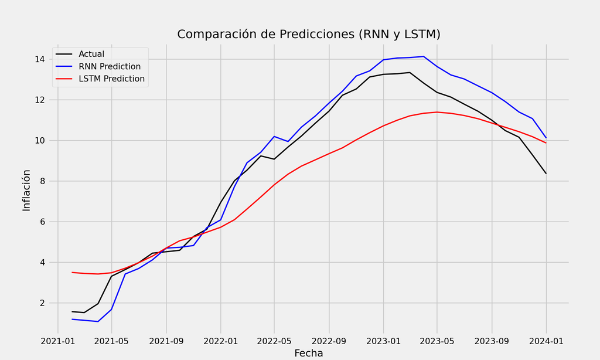

```python
plt.figure(figsize=(10, 6))

# Gráfica para el modelo RNN
plt.plot(y_test_timestamps, y_test_original, label='Actual', color='black')
plt.plot(y_test_timestamps, y_pred_rnn, label='RNN Prediction', color='blue')

# Gráfica para el modelo LSTM
plt.plot(y_test_timestamps, y_pred_lstm, label='LSTM Prediction', color='red')

plt.xlabel('Fecha')
plt.ylabel('Inflación')
plt.title('Comparación de Predicciones (RNN y LSTM)')
plt.legend()
plt.show()
```

```python
mse_rnn = mean_squared_error(y_test_original, y_pred_rnn)
mse_lstm = mean_squared_error(y_test_original, y_pred_lstm)

print(f"RNN MSE: {mse_rnn}")
```

```
## RNN MSE: 0.7932295146079014
```

```python
print(f"LSTM MSE: {mse_lstm}")
```

```
## LSTM MSE: 2.2318303819290386
```

# Conclusión:

[output not shown]